# All practice problems for Quiz 2 on October 3

Due on Monday, October 3, 2016 at 10 AM PDT

# Problem 1

Before finishing and turning in any project, or sharing a project, it is recommended that you run this:

- A. Code Code
- B. Spell Check
- C. Console editor
- D. `?` function

# Problem 2

Which one of these R chunk options dictates whether the code that produces the result should be printed before the corresponding R output:

- A. `eval`
- B. `include`
- C. `echo`
- D. `na.rm`

# Problem 3

Which of the following is one way to correctly extract and list the `police_force_size` data from the `police_resid2` data frame:

- A. `police_resid2 + extract "police_force_size"`
- B. `data = police_resid2, list = police_force size`
- C. `police_resid2$police_force_size`
- D. `police_resid2$c(police_force_size)`

# Problem 4

What would be the most appropriate plot for a situation that was attempting to plot the number of text messages sent daily by gender?

- A. Histogram
- B. Scatterplot
- C. Barplot
- D. Boxplot

# Problem 5

What R chunk would produce a faceted histogram that plots `age` by `orientation`, with a binwidth of 10, and with each orientation a different color?

- ```r
  ggplot(data = profiles, mapping = aes(x = age)) +
    geom_histogram(binwidth = 10, aes(fill = orientation)) +
    facet_wrap(~ orientation)
  ```

- ```r
  ggplot(data = okcupiddata, mapping = aes(x = age)) +
    geom_histogram(binwidth = 10, fill = orientation) +
    facet_wrap(~ orientation)
  ```

- C.

  ```r
  ggplot(data = profiles, mapping = aes(x = age)) +
    geom_histogram(bins = 10, aes(fill = "orientation")) +
    facet_wrap(~ orientation)
  ```

- ```r
  ggplot(data = okcupiddata, mapping = aes(x = age)) +
    geom_bar(binwidth = 10, fill = orientation) +
    facet_wrap(~ orientation)
  ```

# Problem 6

You are asked to produce an appropriate plot for looking at the relationship between `age` and `height`. What kind of plot do you make?

- A. Histogram
- B. Scatterplot
- C. Boxplot
- D. Linegraph

# Problem 7

What makes a data set tidy?

- A. Each variable forms a column.
- B. Each observation forms a row.
- C. Each type of observational unit forms a table.
- D. All of the above.

# Problem 8

A boxplot is used for…

- A. Two numerical variables.
- B. Two categorical variables.
- C. A numerical predictor and a categorical response.
- D. A categorical predictor and a numerical response.

# Problem 9

What is faceting?

- A. It converts data units to physical units.
- B. It creates small multiples of the same plot over a different numerical variable.
- C. It creates small multiples of the same plot over a different categorical variable.
- D. It dictates whether the code that produces the result should be printed before the corresponding R output.

# Problem 10

Which of the following does `aes()`thetic *NOT* affect?

- A. X/Y position
- B. Depth
- C. Color
- D. Size

# Problem 11

What is an appropriate graph to use when plotting a graph for two categorical variables?

- A. Boxplot
- B. Scatter plot
- C. Histogram
- D. Barplot

# Problem 12

What is the most appropriate code for determining the relationship between `sex` and `age`?

- ```r
  ggplot(data = profiles, mapping = aes(x = sex, y = age)) +
    geom_boxplot()
  ```

- ```r
  ggplot(data = profiles, mapping = aes(x = sex, fill = name)) +
    geom_bar()
  ```

- C.

  ```r
  ggplot(data = profiles, mapping = aes(x = age, fill = sex)) +
    geom_bar()
  ```

- ```r
  ggplot(data = profiles, mapping = aes(x = age, y = sex)) +
    geom_boxplot()
  ```

# Problem 13

Why should scatterplots be jittered or points transparent?

- A. For beauty reasons only
- B. The data should only be jittered not also made transparent
- C. Because it is easier to read by reducing overplotting
- D. They shouldn’t

# Problem 14

What graph should be used when dealing with one categorical variable?

- A. Histogram
- B. Scatterplot
- C. Barplot
- D. Boxplot

# Problem 15

Which R chunk produces the most appropriate faceted barplot of `carrier` based on `name`?

- A.

  ```r
  ggplot(data = flights_namedports, mapping = aes(x = carrier, fill = name)) +
    geom_bar() +
    facet_grid(name ~ .)
  ```

- ```r
  ggplot(data = flights_namedports, mapping = aes(x = name, fill = carrier)) +
    geom_bar() +
    facet_grid(. ~ name)
  ```

- C.

  ```r
  ggplot(data = flights_namedports, mapping = aes(x = carrier, fill = name)) +
    geom_bar() +
    facet_grid(carrier ~ .)
  ```

- ```r
  ggplot(data = flights_namedports, mapping = aes(x = name, fill = carrier)) +
    geom_bar() +
    facet_grid(. ~ carrier)
  ```

# Problem 16

What type of plot would be used for a categorical predictor and a numerical response?

- A. faceted bar plot
- B. scatter plot
- C. box plot
- D. histogram

# Problem 17

Why do we use R?

- A. R is free!
- B. R is easily reproducible.
- C. R is set up to be so difficult that no one will succeed.
- D. A and B

# Problem 18

Which of these codes is the most correct?

- A.

  ```r
  ggplot(data = profiles, mapping = aes(x = drugs))
    geom_bar(color = coral, fill = "green", na.rm = TRUE)
  ```

- ```r
  ggplot(data=profiles, mapping= aes(x=drugs)) +
    geom_bar(color= "coral", fill= "green", na.rm = FALSE)
  ```

- C.

  ```r
  ggplot(data = profiles, mapping = aes(x = drugs)) +
          geom_bar(color = "coral", fill = "green", na.rm = TRUE)
  ```

- ```r
  ggplot(mapping = (aes) x = drugs, data = profiles,) +
          geom_bar(color = "coral", fill = "green", na.rm = TRUE)
  ```

# Problem 19

When producing a code for a scatterplot, do we use the `fill` function or the `color` function to change the color of the points?

- A. You use both.
- B. `color`
- C. Neither, you cannot use any type of color on a scatter plot.
- D. `fill`

# Problem 20

Tidy data is…

- A. When the data set is small.
- B. When things are organized in a nice and neat manner.
- C. When each variable forms a row, and the observational unity forms a column.
- D. When each variable forms a column, and the observational unit forms a row, and each type of observational unit forms a table.

# Problem 21

What is one difference between a histogram and a bar plot?

- A. A histogram has bars that touch, a bar plot has bars that do not touch.
- B. A histogram has bars that touch, a bar plot has bars that are a different color, but also touch.
- C. A histogram has bars that do not touch, a bar plot has bars that do touch.
- D. A histogram is a large collection of dots, a bar plot is a line.

# Problem 22

The Code Editor/View Window is?

- A. located at the bottom left corner.
- B. serves as a place to view contents of files and objects in R.
- C. your R sandbox.
- D. all of the above.

# Problem 23

If you would like to list many entries in a `vector` object, you can do so by?

- A. entering `?c` in the R console
- B. using the `View` function
- C. both A and B
- D. none of the above

# Problem 24

Rules for naming objects in R include?

- A. R is case-sensitive.
- B. object names cannot begin with a number.
- C. objects cannot contain symbols that are native to R or are used for mathematics.
- D. all of the above.

# Problem 25

`geom` refers to?

- A. the X and Y position on a plot.
- B. smoothing and binning values.
- C. a type of plot.
- D. adjustments.

# Problem 26

Box plots are best for?

- A. one categorical variable.
- B. one numerical predictor and one numerical response.
- C. one categorical predictor and one numerical response.
- D. one categorical predictor and one categorical response.

# Problem 27

One categorical variable is best displayed in which type of plot?

- A. Histogram
- B. Bar plot
- C. Faceted bar plot
- D. none of the above

# Problem 28

What are the values given in a 5-number Summary?

- A. Minimum, First Quartile, Mean, 3rd Quartile, Maximum
- B. Low Outliers, First Quartile, Median, Third Quartile, High Outliers
- C. Minimum, First Quartile, Median, Third Quartile, Maximum
- D. First Quartile, Median, Third Quartile, Interquartile Range, Outliers

# Problem 29

Which chunk produces the following graph with warning output?

```
## Warning: Removed 9430 rows containing non-finite values (stat_bin).
```

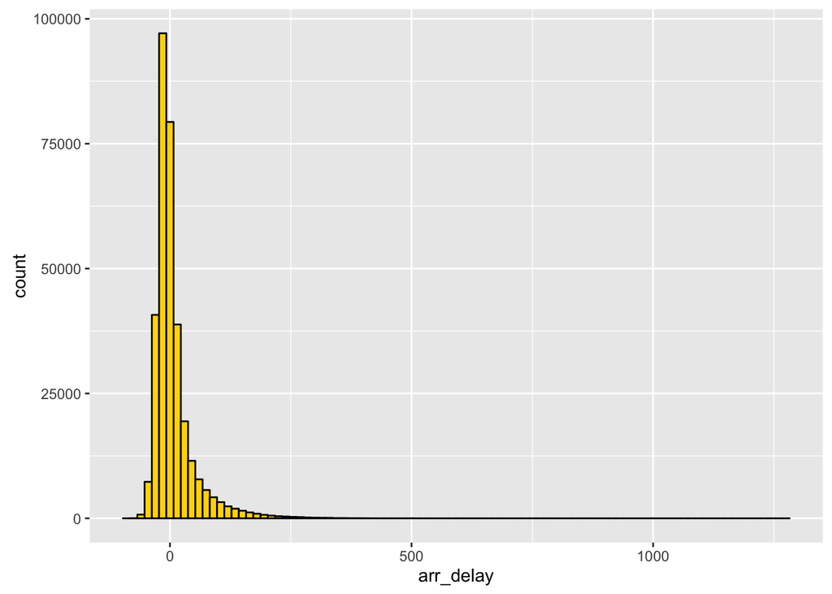

- A.

  ```r
  ggplot(data = flights, mapping = aes(x = arr_delay)) +
    geom_histogram(bins = 1000, color = "black", fill = "gold")
  ```

- ```r
  ggplot(data = flights, mapping = aes(x = arr_delay)) +
    geom_bar(binwidth = 15, color = "black", fill = "gold")
  ```

- C.

  ```r
  ggplot(data = flights, mapping = aes(x = arr_delay, fill = gold)) +
    geom_histogram(bins = 10, color = "black")
  ```

- ```r
  ggplot(data = flights, mapping=aes(x = arr_delay)) +
    geom_histogram(binwidth = 100, color = black, fill = gold)
  ```

# Problem 30

What are the correct definitions of the `echo`, `eval`, and `include` chunk options?

- A. `echo` specifies whether the code AND its output should be in the resulting knitted document, `eval` specifies whether the code should be assessed or just displayed without its output, `include` dictates whether the code that produces the result should be printed before the corresponding R output.
- B. `echo` specifies whether the code should be assessed or just displayed without its output, `eval` dictates whether the code that produces the result should be printed before the corresponding R output, `include` specifies whether the code AND its output should be in the resulting knitted document.
- C. `echo` dictates whether the code that produces the result should be printed before the corresponding R output, `eval` specifies whether the code AND its output should be in the resulting knitted document, `include` specifies whether the code should be assessed or just displayed without its output.
- D. `echo` dictates whether the code that produces the result should be printed before the corresponding R output, `eval` specifies whether the code should be assessed or just displayed without its output, `include` specifies whether the code AND its output should be in the resulting knitted document.

# Problem 31

Given the `flights` data set, what plot would be most appropriate for comparing the variables `carrier` and `arr_delay`?

- A. Faceted Barplot
- B. Scatterplot
- C. Boxplot
- D. Faceted Histogram

# Problem 32

What is NOT a feature of Tidy Data?

- A. Rows correspond to observations
- B. Data converted to Tidy data will be in Wide Format
- C. Data converted to Tidy data will be in Long Format
- D. Both A and B

# Problem 33

What is not a reason we use R?

- A. R only costs a few dollars to use
- B. R is reproducible
- C. R helps you find answers quickly
- D. R makes it easy to collaborate

# Problem 34

What is not the name of a type of graph?

- A. Box plot
- B. Flat plot
- C. Histogram
- D. Bar plot

# Problem 35

Which one is not a panel seen on RStudio?

- A. Checker
- B. History
- C. Console
- D. Environment

# Problem 36

What is not a key element of tidy data?

- A. variables
- B. values
- C. observational unit
- D. graph

# Problem 37

What is not a component of Hadley Wickham’s workflow graphic?

- A. Untidy
- B. Import
- C. Communicate
- D. Understand

# Problem 38

Which one of the following is a valid R code for a faceted plot?

- A. `facet_grid()`
- B. `Facets()`
- C. `facet_wrap()`
- D. A and C

# Problem 39

What plot would correspond to a data set that compares one continuous numerical variable to one categorical variable?

- A. Bar plot
- B. Histogram
- C. Scatter plot
- D. Box plot

# Problem 40

When usually would be a good reason to use a line graph over a scatter plot?

- A. When you want to connect the dots to make a picture of a puppy
- B. When the x-axis is time and each time point corresponds to one y value
- C. If you are comparing a numerical variable to a categorical variable
- D. If the scatter plot code you enter results in an error

# Problem 41

What does it mean to “jitter” the points on a plot?

- A. To shake the points a bit on the plot
- B. To remove some of the over-plotting
- C. To add “random noise” to the points to better see them
- D. All of the above

# Problem 42

What reason did Naomi Robbins, author of “Creating More Effective Graphs”, for why we shouldn’t use pie charts?

- A. They do not look professional
- B. We often overestimate angles greater than 90 degrees and we underestimate angles less than 90 degrees
- C. Histograms are more efficient for categorical data and make it easier to analyze data
- D. The word “pie” is a distraction from the data analysis

# Problem 43

What are the main features of a tidy data set?

- A. Observational units form columns and variables are in the rows
- B. All variables are in one column and observational units are in the rows
- C. A single variable forms a single column and all observations are in a row
- D. Each observation is in a row and each single variable is a column

# Problem 44

If you want to plot two variables, where the explanatory is categorical and the response is numeric, which types of graphs would be appropriate to use?

- A. Faceted barplot & faceted histogram
- B. Faceted histogram & line graph
- C. Boxplot & faceted barplot
- D. Boxplot & faceted histogram

# Problem 45

If you want to plot two categorical variables which type of graph would be the most appropriate to use?

- A. Boxplot
- B. Bar plot
- C. Faceted barplot
- D. Faceted histogram

# Problem 46

What is the difference between a faceted histogram and a faceted barplot?

- A. A faceted histogram is used for two categorical variables and a faceted barplot is best for one categorical and one numeric variable
- B. A faceted barplot is used for two categorical variables and a faceted histogram is used for a numeric explanatory variable and a categorical response variable
- C. A faceted barplot shows two categorical variables and a faceted histogram shows two numeric variables
- D. A faceted histogram is for plotting a categorical explanatory variable and a numeric response variable while a faceted barplot is for plotting a categorical explanatory and categorical response variable

# Problem 47

What is one thing the `factor` function does?

- A. Counts how many pieces of data there are for a given variable
- B. Turns a continuous variable into a discrete variable
- C. Turns a discrete variable into a categorical variable
- D. Tells you what type of variable (categorical, numeric, integer) something is

# Problem 48

Which of these would produce a side by side barplot of `status` faceted by `sex` with `fill` color determined by `orientation`?

- A.

  ```r
  ggplot(data = profiles, aes(status, fill = orientation)) +
    geom_bar() +
    facet_wrap(~sex) +
    (position = "dodge")
  ```

- ```r
  ggplot(data = profiles, aes(status, fill = orientation)) +
    geom_bar(position = "dodge") +
    facet_wrap(~sex)
  ```

- C.

  ```r
  ggplot(data = profiles, aes(status, fill = orientation)) +
    geom_bar() +
    facet_wrap(~sex)
  ```

- ```r
  ggplot(data = profiles, aes(status, fill = orientation)) +
    geom_bar(position = dodge) +
    facet_wrap(~sex)
  ```

# Problem 49

Which of these will give us rows 9 through 12 of the variable `distance` in the `flights` data set?

- A. `flights$distance[9:12]`
- B. `flights$distance[-9:12]`
- C. `flights$distance[c(9, 12)]`
- D. `flights$distance [-c(8, 13)]`

# Problem 50

Which of these plots is not used when the explanatory variable is categorical?

- A. Faceted barplot
- B. Boxplot
- C. Faceted histogram
- D. Scatterplot

# Problem 51

If you were to compare two variables such as percentage of voters by region, what plot would you use to display this distribution of data?

- A. Barplot
- B. Boxplot
- C. Histogram
- D. Scatterplot

# Problem 52

What is the purpose of *jittering* when you have a large mass of points in a *Scatterplot*?

- A. This function helps when there is a large mass of points because it makes the plot look nicer and saves you from confusion.
- B. This function helps when there is a large mass of points because it allows you to shake the points a bit on the plot and fix overplotting.
- C. This function helps when there is a large mass of points because it allows you to add just a bit of random noise to the points to better see them.
- D. All of the above.

# Problem 53

What 2 functions are most crucial when producing a faceted barplot?

- A.`factor` and `geom_bar` functions
- B.`geom_bar` and `facet_grid` functions
- C.`bins` and `facet_grid` functions
- D. None of the above.

# Problem 54

Which of the following would be the result of running the following R code in the Console?

`> library(okcupiddata)`

- A. R will load the `okcupiddata` package if the package is installed.
- B. R will allow you to view the `okcupiddata` dataset.
- C. It will allow you to remove the missing values in the `okcupiddata` dataset.
- D. All of the above.

# Problem 55

Why is the `labs` function useful in keeping your data distributions organized?

- A.The `labs` function is useful because it allows you to label the **x** and **y** axis.
- B.The `labs` function is useful because it allows you to change the default labels on the plot and add a title.
- C.The `labs` function is useful because others are able to receive clarification of the data distribution, with the help of labels.
- D. All of the above.

# Problem 56

How are tidy datasets formed?

- A. Variables in columns, observations in rows and values in the table.
- B. Values in columns, variables in rows and observations in the table.
- C. Observations in columns, values in rows and variables in the table.
- D. None of the above.

# Problem 57

If a dataset called `class_examscore` included 10 students names and grades that they received on three exams, how would you extract the first five student names in the dataset?

- A. `class_examscore$name[1:5]`
- B. `class_examscore$name(c(1, 5))`
- C. `class_examscore$name1:5`
- D. None of the above

# Problem 58

A faceted barplot is most likely used when you are graphing….

- A. Two categorical variables
- B. Two numerical variables
- C. One categorical variables
- D. One numerical variables

# Problem 59

To produce a histogram with 4 bins, fill color blue and border color green, what would the ending of the R chunk look like?

- A. `geom_histogram(bins = 4, color = "green", fill = "blue")`
- B. `geom_histogram(bins = 4, color = green, fill = blue)`
- C. `geom_histogram(bins = 4, color = "blue", fill = "green")`
- D. `geom_histogram(bins = 4, color = blue, fill = green)`

# Problem 60

When would sometimes using the median be better and more reliable than using the mean?

- A. The outliers won’t have a large impact on the median of values.
- B. You should never use the median, always use the mean of the values.
- C. The median may be a smaller value to the mean.
- D. The median is easier to obtain.

# Problem 61

Which code below corresponds to a histogram with 10 bins, a black outline, and a blue fill (assuming the appropriate call to `ggplot` with a `+` was made just before this)?

- A. `ggplot(binwidth = 10, color = "white", fill = "forestgreen")`
- B. `geom_histogram(binwidth = 10, color = "black", fill = "blue")`
- C. `geom_histogram(bins = 10, color = "black", fill = "blue")`
- D. `geom_boxplot(binwidth = 10, color = "black", fill = "blue")`

# Problem 62

What is known as the five-number summary?

- A. Minimum value, 1st quartile value, 2nd quartile value, 3rd quartile value, maximum value
- B. The average of the first five numbers in the data set.
- C. Minimum value, 1st quartile value, median, mean, 3rd quartile value
- D. Minimum value, median, mean, maximum value, missing values

# Problem 63

What is the biggest problem with pie charts compared to barplots?

- A. Difficult to determine relative size of each piece because it is hard to judge angles.
- B. Too many colors make it harder for someone to read the graph.
- C. Uses percentages which is harder to analyze data with.
- D. Pie charts are unable to weed out the unnecessary data points.

# Problem 64

“`Error: could not function 'ggplot'`” appears in the R Console after running:

```r
ggplot(data = alaska_flights, aes(x = dep_delay, y = arr_delay)) +
   geom_point(alpha = 0.2)
```

What needs to be done to fix this error?

- A. You need to put `ggplot2` rather than `ggplot` in your code.
- B. `ggplot` is a function in `ggplot2`, so you need to make sure `ggplot2` is loaded via `library(ggplot2)` in a chunk above this chunk.
- C. The `g` in `ggplot` needs to be capitalized: (`Ggplot`)
- D. None of the above.

# Problem 65

What does the following code do when it is run in R? (assuming that we have downloaded the `police_resid2` data and loaded the `ggplot2` package)?

```r
ggplot(data = police_resid2, mapping = aes(x = white)) +
  geom_histogram(bins = 5, color = "white", fill = "red")
```

- A. Displays a graph with 5 red colored bins
- B. Creates a histogram on the `white` variable using the `police_resid2` data
- C. Highlights the border of the bars in the plot with white color
- D. All the above

# Problem 66

What does NOT make a dataset tidy?

- A. Each variable forms a row.
- B. Each variable forms a column.
- C. Each type of observational unit forms a table.
- D. Each observation forms a row.

# Problem 67

Below are a few of the symbols and panes that are the most common within RStudio. Find the incorrect symbol or pane description.

- A. The assignment operator is denoted by `<-` . You can read this as putting your contents of the left-hand-side into an object name whenever it appears in the right-hand-side.
- B. The “History” tab allows you to store all of the codes in a file and then “run” that code whenever needed.
- C. The “Viewer” tab shows the resulting HTML file created from the R Markdown “Knit.”
- D. The “Plots” tab allows you to create graphs and/or figures without any code.

# Problem 68

When would it be most appropriate to use a boxplot?

- A. To compare the distribution of one or more quantitative variables across multiple levels of one categorical variable.
- B. To compare and contrast the distribution of one quantitative variable across multiple levels of one categorical variable.
- C. To contrast the distribution of one quantitative variable across multiple levels of one categorical variable.
- D. To visualize the frequency of different categories of a categorical variable.

# Problem 69

What can be done when missing values from a data set need to be excluded from analysis?

- A. `na.rm = TRUE`
- B. `narm = FALSE`
- C. `na = TRUE`
- D. `na.rm = FALSE`

# Problem 70

Carefully analyze the code below:

```r
if(!require("ggplot2"))
  install.packages("ggplot2", repos = "http://cran.rstudio.org")
library(ggplot2)
ggplot(data = weather, mapping = aes(x = temp))
```

If you wanted to produce a histogram, would the code above plot a histogram? Why or why not?

- A. Yes. The code above specifically allows RStudio to plot the dataset.
- B. No. The code just provided a backdrop. We need to be able to plot, thus we will follow up the code with a “+”. As seen in the code below.

  ```r
  ggplot(data = weather, mapping = aes(x = temp)) +
    geom_histogram()
  ```

- C. Yes. The code above has provided the backdrop and added the layer needed to plot.
- D. No. The code just provided a backdrop. We need to be able to plot, thus we will begin the following line with a “+”. As seen in the code below.

  ```r
  ggplot(data = weather, mapping = aes(x = temp))
    + geom_histogram()
  ```

# Problem 71

Which plot is appropriate to plot the relationship between `sex` and `education` in the `profiles` `okcupiddata` data set?

- A. Barplot
- B. Faceted Barplot
- C. Histogram
- D. Faceted Histogram

# Problem 72

Which code will correctly produce the appropriate plot (though it won’t be a really nice thing to look at…) to plot `sex` and `education` in the `profiles` `okcupiddata` data set?

- A.

  ```r
  ggplot(data = profiles, mapping = aes(x = education)) +
   geom_histogram(aes(fill = education), na.rm = TRUE)
  ```

- B.

  ```r
  ggplot(data = profiles, mapping = aes(x = education)) +
    geom_bar(aes(fill = "education"), na.rm = TRUE) +
    facet_wrap(~sex)
  ```

- C.

  ```r
  ggplot(data = profiles, mapping = aes(x = education))+
   geom_bar(aes(fill = education), na.rm = TRUE) +
    facet_wrap(~ethnicity)
  ```

- ```r
  ggplot(data = profiles, mapping = aes(x = education)) +
    geom_bar(aes(fill = education), na.rm = TRUE) +
    facet_wrap(~sex)
  ```

# Problem 73

What is the correct code to produce this graph?

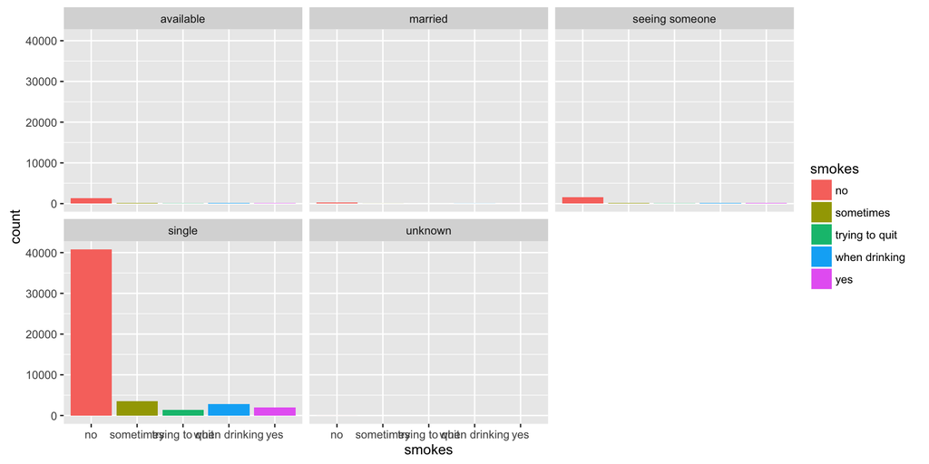

- ```r
  ggplot(data = profiles, mapping = aes(x = smokes)) +
    geom_bar(aes(fill = smokes), na.rm = TRUE) +
    facet_wrap(~status)
  ```

- B.

  ```r
  ggplot(data = profiles, mapping = aes(y = smokes)) +
    geom_boxplot(aes(fill = smokes), na.rm = TRUE) +
    facet_wrap(~status)
  ```

- C.

  ```r
  ggplot(data = profiles, mapping = aes(x = smokes)) +
    geom_bar(aes(fill= "smokes"), na.rm = TRUE) +
    facet_wrap(~status)
  ```

- D.

  ```r
  ggplot(data = profiles, mapping = aes(x = status)) +
    geom_bar((aes(fill = smokes, na.rm = TRUE))) +
    facet_wrap(~smokes)
  ```

# Problem 74

How does the placement of a `~` affect the display of the plot? For example, if it is `facet_grid(. ~ size)` compared to `facet_grid(size ~ .)`?

- A. The placement of the `~` does not effect the plot display in this case.
- B. The levels of `size` are displayed on the top of the graph with `(. ~ size)`
- C. The levels of `size` are displayed on the right-hand-side of the graph `(size ~)`
- D. Answers B and C

# Problem 75

When a plot is skewed to the right it…?

- A. Has large humps on the left
- B. Has large humps on the right
- C. Is bell shaped
- D. None of the above

# Problem 76

When using two categorical variables, what is the most appropriate plot to use?

- A. Boxplot
- B. Scatter-plot
- C. Barplot
- D. Faceted Bar

# Problem 77

What precisely does the “box” of a boxplot represent?

- A. 0th, 50th, and 100th percentiles
- B. Below average, average, above average
- C. 25th, 50th and 75th percentiles
- D. Answers A and B

# Problem 78

What is needed to make the following chunk of code correct?

```r
ggplot(data = profiles, mapping = aes(x = drugs)) +
  geom_bar(color = "white", (fill = drugs), na.rm = TRUE)
```

- A. `(fill = "drugs")`
- B. `, (na.rm = TRUE))`
- C. `aes(fill = drugs)`
- D. None of the above

# Problem 79

What is the `c` function used for?

- A. Listing out entries and putting them into a vector object
- B. Checking to see what type an object is
- C. Categorizing different variables in a data set
- D. Changing the color of histogram bins

# Problem 80

How would we extract entries 2-34 from a variable of 72 entries?

- A. `[c(2-34)]`
- B. `[c(2,34)]`
- C. `[-c(2,34)]`
- D. `[2:34]`

# Problem 81

Which of the following code is needed to produce a faceted histogram of `age` based on and colored by `sex` using the data set `profiles` from `okcupiddata`?

- A. `mapping = aes(x = age, fill = sex)`
- B. `mapping = aes(x = sex, fill = age)`
- C. `mapping = aes(x = age, y = sex)`
- D. `mapping = aes(x = sex, y = age)`

# Problem 82

What type of graph is included in mapping two categorical variables?

- A. Histogram
- B. Barplot
- C. Boxplot
- D. Scatterplot

# Problem 83

What function do I use to label/rename parts of a graph?

- A. `aes`
- B. `ggplot`
- C. `labs`
- D. `wrap`

# Problem 84

What are the five named graphics (5NG)?

- A. Histograms, Boxplots, Pie chart, Scatter plot, Line graph
- B. Boxplot, Scatter plot, Line plot, Histogram, Barplot
- C. Scatter plot, Histogram, Boxplot, Pie chart, Pictograph
- D. None of the above

# Problem 85

Which code is correct for producing a histogram with the `rain` variable with specified bins and color with no warning messages?

- ```r
  ggplot(data = weather, mapping = aes(x = rain)) +
    geom_histogram(binwidth = 10, fill = "limegreen", color = "black", na.rm = TRUE)
  ```

- ```r
  ggplot(data = weather, mapping = aes(x = rain, y = humid)) +
    geom_histogram(binwidth = 10, fill = "limegreen", color = "black", na.rm = TRUE)
  ```

- ```r
  ggplot(data = weather, mapping = aes(x = rain)) +
    geom_boxplot(binwidth = 10, fill = "limegreen", color = "black", na.rm = TRUE)
  ```

- D.

  ```r
  ggplot(data = weather, mapping = aes(x = rain)) +
    geom_histogram(fill = "limegreen", color = "black", na.rm = TRUE)
  ```

# Problem 86

Which of the following is most appropriate for plotting the temperature in Oregon for the past month?

- A. Box plot
- B. Scatter plot
- C. Faceted barplot
- D. Histogram

# Problem 87

What does skewed right mean when looking at a bar plot?

- A. A majority of the data falls near the center of the graph
- B. A majority of the data falls near the right side of the graph
- C. A majority of the data falls near the left side of the graph
- D. None of the above.

# Problem 88

Which of the following is the best option for comparing the distributions of two variables that are not categorical?

- A. You should never compare two variables
- B. Histograms
- C. Barplots
- D. None of the above

# Problem 89

How do you plot the relationship between `age` and `height`?

- ```r
  ggplot(data = profiles, mapping = sex, height) +
    geom_histogram()
  ```

- B.

  ```r
  ggplot(data = profiles, aes(x = age, y = height)) +
    geom_bar()
  ```

- C.

  ```r
  ggplot(data = profiles, aes(x = age, y = height)) +
    facet_histogram(na.rm = TRUE)
  ```

- D.

  ```r
  ggplot(data = profiles, aes(x= age, y= height)) +
    geom_point(na.rm = TRUE)
  ```

# Problem 90

Which of the following would be most appropriate when plotting one numerical and one categorical variable?

- A. Box Plot
- B. Histogram
- C. Bar plot
- D. Faceted histogram

# Problem 91

Which chunk would create a faceted histogram of `sex` and `age`, with border color pink, and fill color based on the values of `smokes`, and 20 bins?

- A.

  ```r
  ggplot(data = profiles, mapping = (x = age, y = sex)) +
    geom_histogram(bins = 20, color = pink, fill = smokes)
  ```

- B.

  ```r
  ggplot(data = profiles, mapping = aes(x = age)) +
    geom_histogram(bins = 20, color = "pink", aes(fill = smokes)) +
    facet_grid(~sex)
  ```

- C.

  ```r
  ggplot(data = profiles, mapping = aes(x=age, y=sex)) +
           geom_histogram(bins = 20, color = pink, fill = "smokes")
  ```

- D.

  ```r
  ggplot(data=profiles, mapping=aes(x=age))+
    geom_histogram(bins=20, color = "pink", aes(fill = smokes)) +
    facet_plot(sex)
  ```

# Problem 92

Why do we wrap things in `aes`?

- A. It reminds R that the values specified vary and aren’t fixed like a specific color.
- B. Any specified color for fill or border needs to be wrapped in `aes`
- C. All geometries must be wrapped to remind R that they plot values.
- D. None of the above.

# Problem 93

What is the biggest difference between a bar plot and a histogram?

- A. Bar plot looks at 2 variables, histogram looks at 1
- B. Histogram looks at 2 variables, bar plot looks at 1 variable
- C. Histograms plot continuous variables, barplots plot categorical variables.
- D. Histogram bars does not touch, barplot has continuous data and, thus, touching bars

# Problem 94

What two types of variables do box plots compare?

- A. Categorical, Numerical
- B. Categorical, categorical
- C. Numerical, Numerical
- D. All of the above

# Problem 95

What does the code look like for a histogram?

- A. `ggplot(data = , mapping = aes(x = )) + geom_histogram()`
- B. `ggplot(data= , mapping = (x = )) + geom_histogram()`
- C. `ggplot(data= , mapping = (aes=)) + geom_histogram ()`
- D. `ggplot(data= , mapping = aes(x = )) + create_histogram()`

# Problem 96

What types of variables does a scatterplot graph?

- A. categorical, categorical
- B. categorical, numerical
- C. numerical, numerical
- D. none of the above

# Problem 97

How do you set the transparency of `point`s?

- A. `alpha =`
- B. `trans =`
- C. `add =`
- D. not possible

# Problem 98

Why should you use a lineplot?

- A. Great way to look at trends over time
- B. You should never!
- C. When you have a natural ordering to `x` and one corresponding value of `y` for each `x` value.
- D. Both A and C